# chapter-4

Early Positive School Perspectives of Criminality

## Pseudoscience

A collection of beliefs or practices mistakenly regarded as being based on scientific method or evidence.

Characteristics:

1.) Lacks empirical support or testability.

2.) Relies on anecdotal evidence or subjective validation.

3.) Often resistant to criticism or revision.

*Example:* Astrology - the belief that celestial bodies influence human behavior and personality traits.

[figure not shown]

image: giphy

# EVERYTHING YOU ARE ABOUT TO HEAR IS A PSEUDOSCIENCE!

## Eugenics

The study and implementation of policies aimed at improving the human race through controlled reproduction, often enforced on specific groups.

Individuals were classified into “superior” and “inferior” groups based on perceived genetic traits.

Linked criminal behavior to heredity and advocating for selective reproduction to reduce crime.

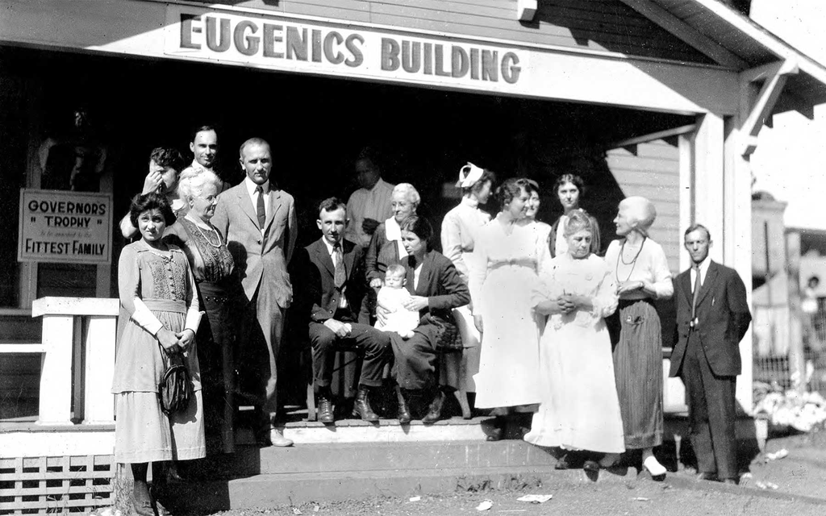

image: Cold Spring Harbor

## Craniometry

The study of skull and brain size as indicators of superiority or inferiority among individuals or racial/ethnic groups.

Skull size and shape were believed to reflect brain capacity, with larger skulls indicating higher intelligence and moral superiority.

Used to justify racial hierarchies and discriminatory policies that linked traits to criminal behavior.

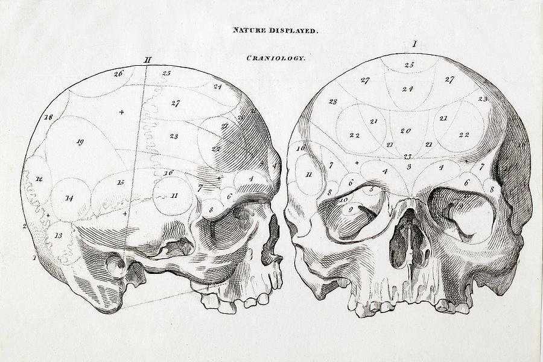

Image: Science Photo Gallery

Claimed to assess personality traits by analyzing skull shape and bumps.

Believed skull contours matched brain structure, linking specific areas to mental faculties or behaviors.

Influenced criminology by tying criminal tendencies to physical traits, stigmatizing certain groups.

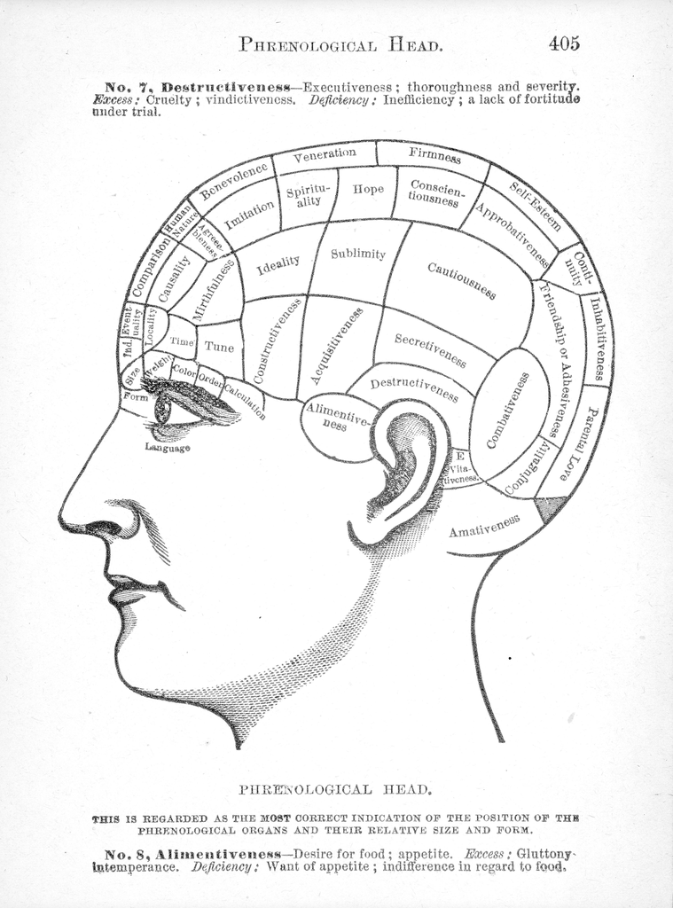

Image: Carnegie Mellon University

[figure not shown]

Image: giphy

# THIS NEXT SLIDE IS NOT PSEUDOSCIENCE!

## On the Origin of Species (1859)

**Charles Darwin**

Foundation of modern biology and genetics.

Explains species change via natural selection

Key Points:

Variation: Genetic differences exist within a population

Competition: Organisms compete for limited resources

Adaptation: Beneficial traits improve survival

Natural Selection: Favorable traits are passed on

Speciation: Accumulated changes lead to new species

[figure not shown]

## WE ARE BACK TO THE PSEUDOSCIENCE!

[figure not shown]

Image: giphy

## Misuse of Darwin’s On the Origin of Species

**Francis Galton** created Social Darwinism

Misapplied natural selection to human societies, using “survival of the fittest” to justify social inequality and group dominance.

Claimed intelligence, morality, and criminality were hereditary, advocating reproduction for the “fit” and restrictions for the “unfit.”

Provided a pseudoscientific basis for discriminatory policies like forced sterilizations and immigration controls, framed as improving the human race.

## Lombroso’s Theory of Atavism and the “Born Criminal”

The Criminal Man (1876), which propagated Atavism

Criminals are evolutionary “throwbacks” to primitive humans, exhibiting physical, mental, and behavioral traits of earlier stages of human development.

Certain individuals are biologically predisposed to criminal behavior, identifiable through physical stigmata (e.g., asymmetrical faces, large jaws, sloping foreheads).

Pioneered the positivist school of criminology, shifting focus from free will to biological determinism in explaining criminal behavior.

## Intelligence Quotient (IQ)

Alfred Binet developed IQ testing to identify under performing students, where he had children do tasks such as follow commands, copy patterns, name objects, and put things in order or arrange them properly.

Believed IQ could change over time

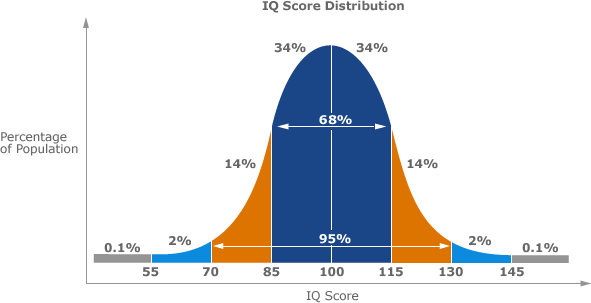

Image: Lumen Learning

## IQ and Eugenics

H.H. Goddard took Binet’s ideas to propagate eugenic policies.

Claimed IQ was static and inherited.

Introduced the concept of “feeblemindedness” to label individuals with below-average IQ.

Created a ranking system to categorize intelligence levels.

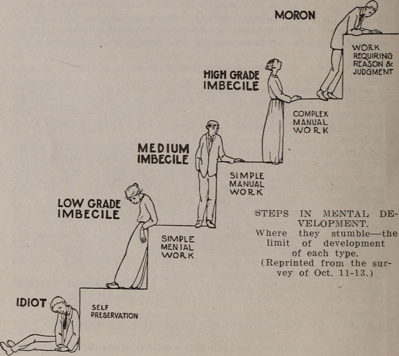

Image: American Scientist

## *Buck v. Bell*

A 1927 Supreme Court case that upheld Virginia’s law allowing the sterilization of Carrie Buck, a woman who was deemed “feeble-minded”.

Her condition had been present in her family for the last three generations. Justice Holmes declared, “Three generations of imbeciles are enough.”

[NPR Podcast](https://www.npr.org/2017/03/24/521360544/the-supreme-court-ruling-that-led-to-70-000-forced-sterilizations)

# Group Discussion!!!

## Group Discussion!!!

`10:00`

As mentioned last class, [“risk assessment” tools](https://www.publicsafety.gc.ca/cnt/rsrcs/pblctns/rsk-nd-rspnsvty/index-en.aspx) for bail or sentencing use data-driven methods to predict recidivism.

To what extent do these algorithms risk falling into a new form of biological determinism or social bias reminiscent of Lombroso’s “born criminal” argument?

Elect one speaker to present your argument.

## Questions for Exam

[figure not shown]

Image: giphy

## Good luck studying!!!

[figure not shown]

Image: giphy